# Aphantasia_analysis

Corey

01/02/2024

Aphantasia is a recently described condition in which the individual does not exprience mental imagery. For example, when asked to visualize an apple in your mind’s eye, most of use would internally conjure an image of an apple, as if we were actually seeing it. For those with aphantasia, this internal image is often interpreted as a metaphor, and they often report thinking of the apple semantically (“I know it is a round red fruit”)

In this study, we were interested in investigating how individuals with aphantasia process visual information. In particular, we wanted to see if their visual processing is more or less robust than that of individuals who do not have aphantasia.

Here we had them complete a visual categorization task. Briefly, on each trial an image of an object was presented for a short duration (for 25 ms, 50 ms, 75 ms, 100 ms, or 150 ms), and participants were required to identify which category the object belonged to (Clothing, Food, Tools, Toys).

There were two critical manipulations. First is that on 80% of the trials, the images were presented in a partially occluded manner in which portions of the image were presented through bubbles. This requires participants to mentally fill in the rest of the image in order to successfully identify and categorize the object.

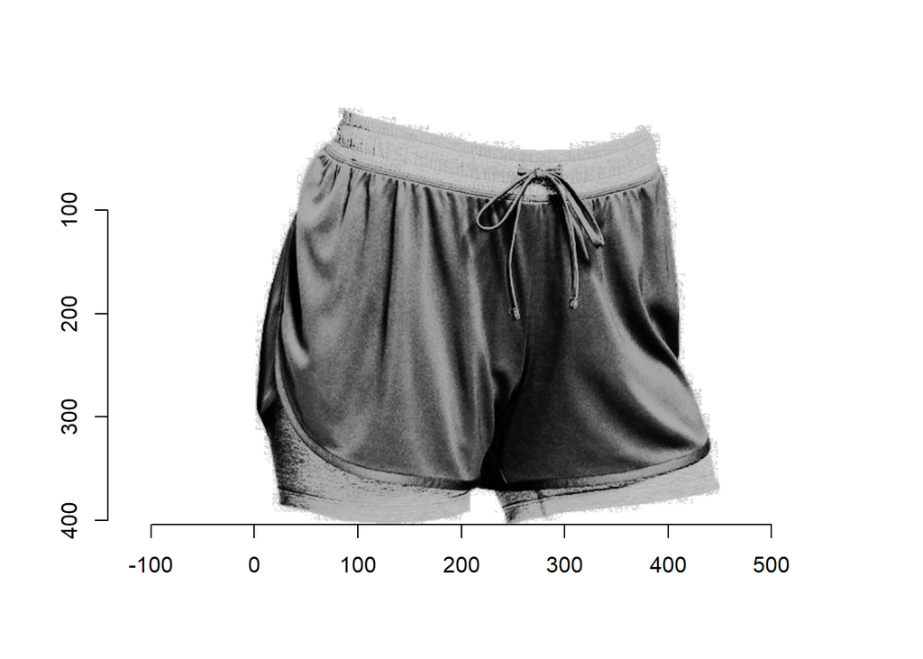

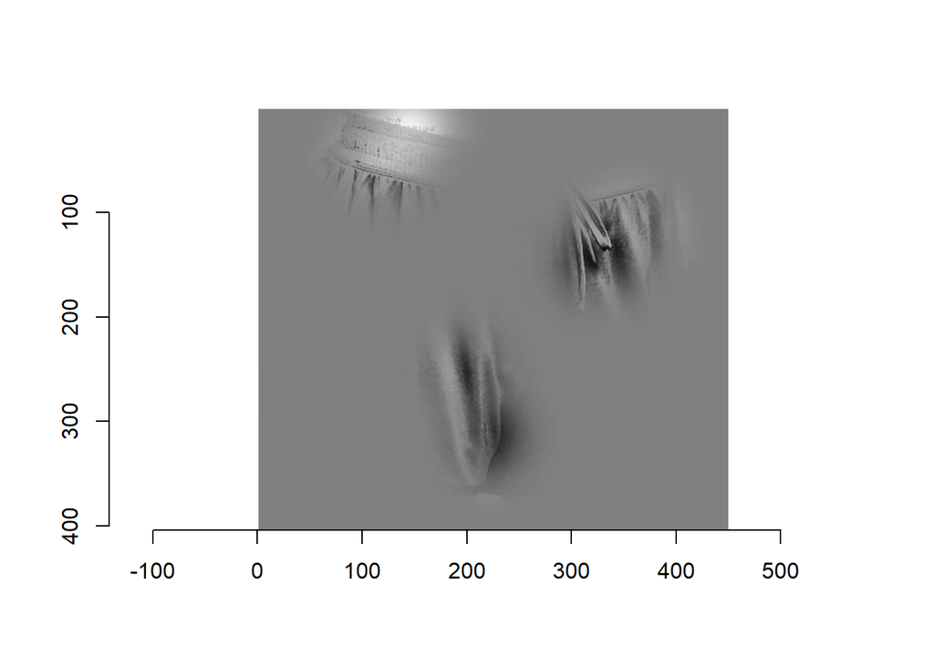

Second is that on 50% of the trials, the images were followed by a visual noise mask (referred to as back masking). This noise mask is intended to disrupt visual processing, specifically the mental operation of filling in the missing portions of the image.

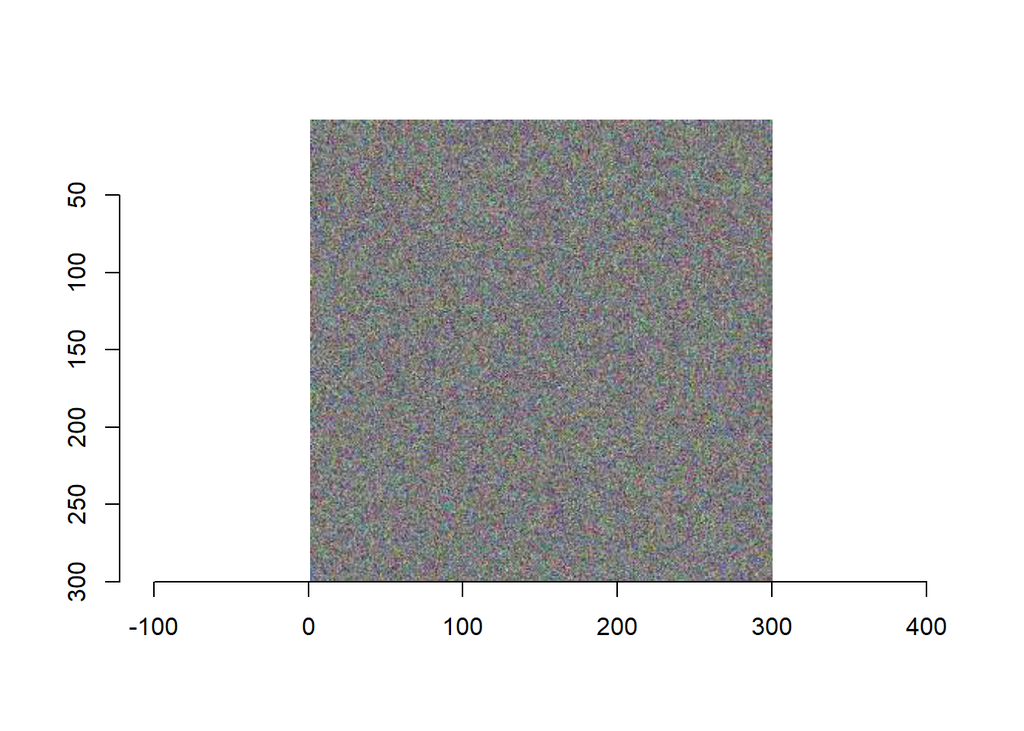

Given that individuals with aphantasia operate on more abstract terms, we were interested in seeing how, if at all, their visual processing would be disrupted by visual noise.

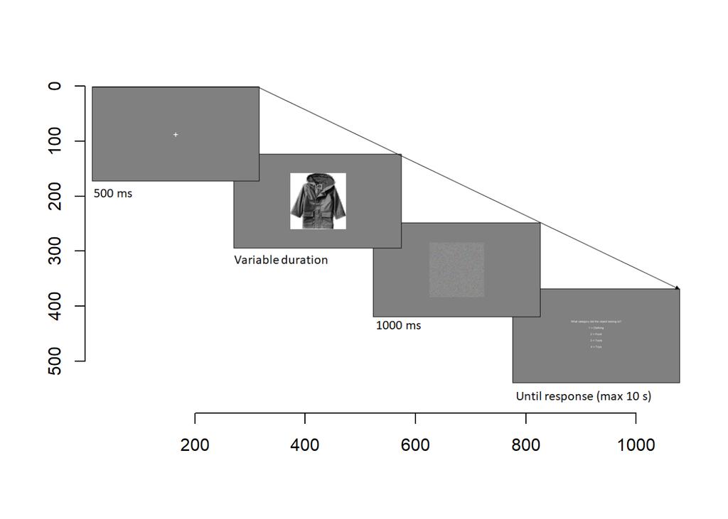

# Accuracy Analysis

Here we present accuracy for the categorization task.

The left graph is data from participants *with aphantasia*. The right is control data of participants *without aphantasia*

## Partially occluded images

These graphs show categorization accuracy for backmasked vs unmasked images for *partially occluded images* against stimulus duration.

Performance increases with stimulus duration. It’s easier to categorize when you see the image for longer. Performance also decreases with back masking. The presentation of visual noise following the image inhibits categorization performance.

These patterns are present for both participants with Aphantasia and participants from Prolific.

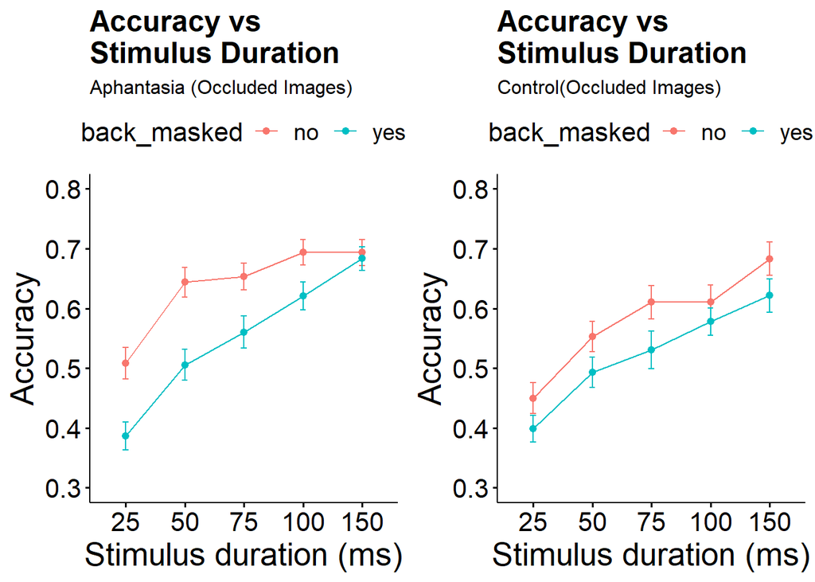

## Unoccluded images

This second set of graphs that examines accuracy for images that were *not obstructed with bubbles (seen at 100% visibility)*

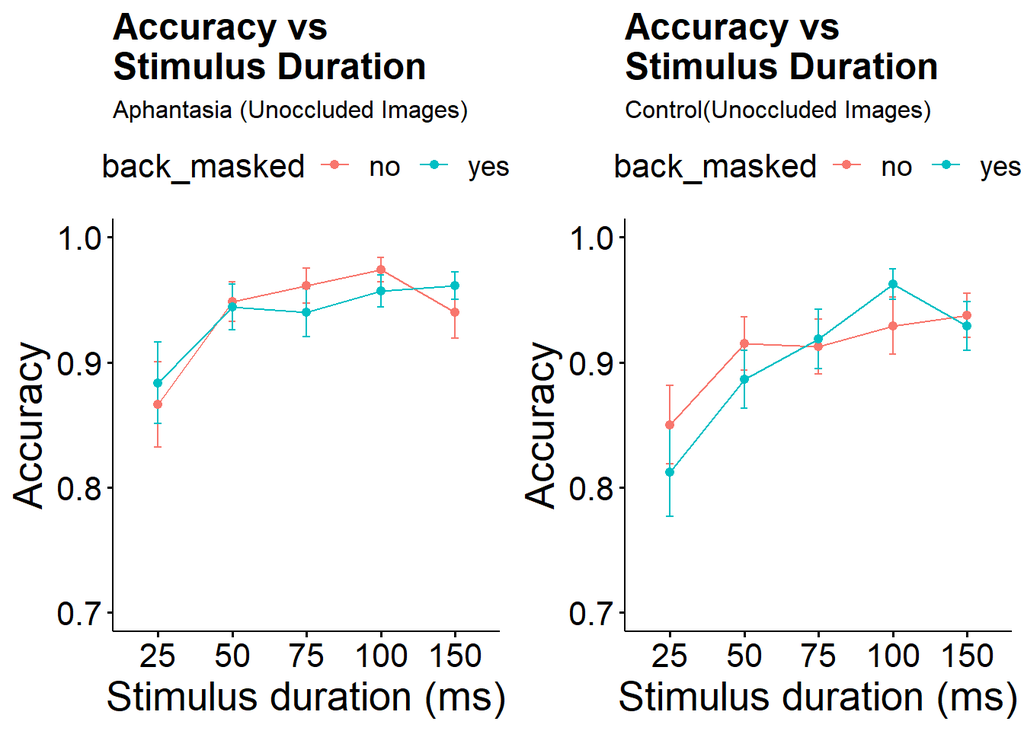

### Modeling Accuracy

#### Occluded Images

We ran a linear mixed effects model to test trends seen in the above graphic. The model includes stimulus duration (SOA), back masking, and aphantasia group as fixed effects and participant as a random intercept.

Accuracy ~ Stimulus_duration x back_masking x aphantasia + (1|participant)

The model revealed significant effects of stimulus duration and backmasking. Accuracy increase the longer the image is on screen and decreases when the image is back masked by visual noise.

There’s also an interaction between aphantasia and back masking. This indicates that the aphantasia group was more greatly affected by the visual noise, *suggesting that their visual processing is less robust and more vulnerable to disruption*.

|  | Accuracy |  |  |
| --- | --- | --- | --- |
| Predictors | Estimates | CI | p |
| (Intercept) | 0.45 | 0.40 – 0.49 | **<0.001** |
| SOA | 0.00 | 0.00 – 0.00 | **<0.001** |
| back masked [yes] | -0.06 | -0.11 – -0.01 | **0.018** |
| aphantasia2 [yes] | 0.09 | 0.02 – 0.16 | **0.012** |
| SOA * back masked [yes] | 0.00 | -0.00 – 0.00 | 0.977 |
| SOA * aphantasia2 [yes] | -0.00 | -0.00 – 0.00 | 0.132 |
| back masked [yes] * aphantasia2 [yes] | -0.11 | -0.18 – -0.04 | **0.002** |
| (SOA * back masked [yes]) * aphantasia2 [yes] | 0.00 | 0.00 – 0.00 | **0.010** |
| Random Effects |  |  |  |
| σ<sup>2</sup> | 0.01 |  |  |
| τ<sub>00</sub> <sub>participant</sub> | 0.01 |  |  |
| ICC | 0.50 |  |  |
| N <sub>participant</sub> | 59 |  |  |
| Observations | 590 |  |  |
| Marginal R<sup>2</sup> / Conditional R<sup>2</sup> | 0.279 / 0.638 |  |  |

#### Unoccluded Images

Here’s the same model but for images presented without bubbles (100% visibility)

[output not shown]

## Reaction Time Analysis

We also wanted to see then if participants with Aphantasia were slower at responding during the categorization task, which could reflect a difference in cognitive strategy or difference in the nature of the representations that they have to access to identify the object.

These graphs show categorization reaction time for backmasked vs unmasked images for *partially occluded images* against stimulus duration.

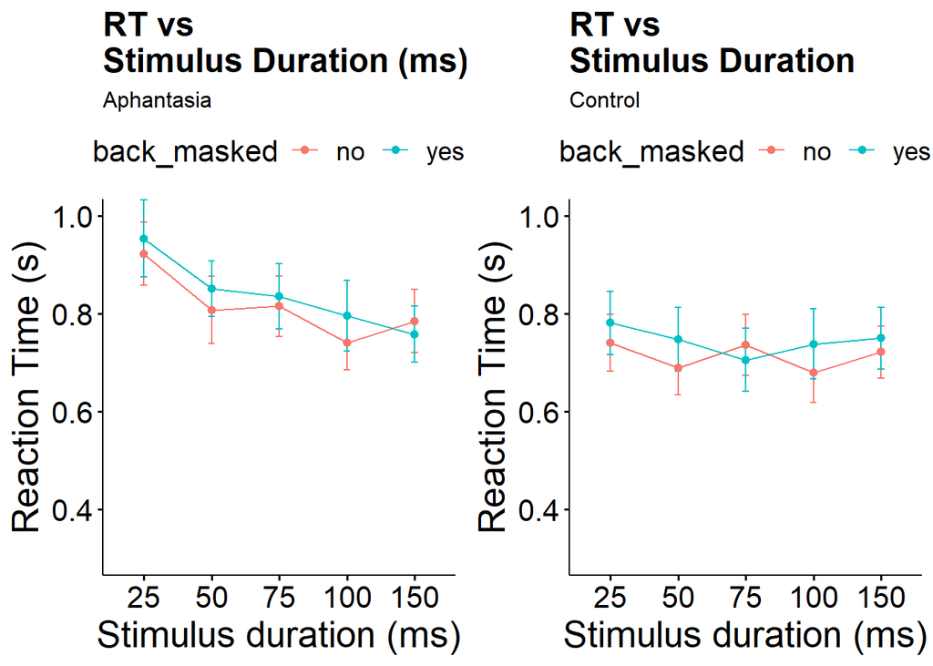

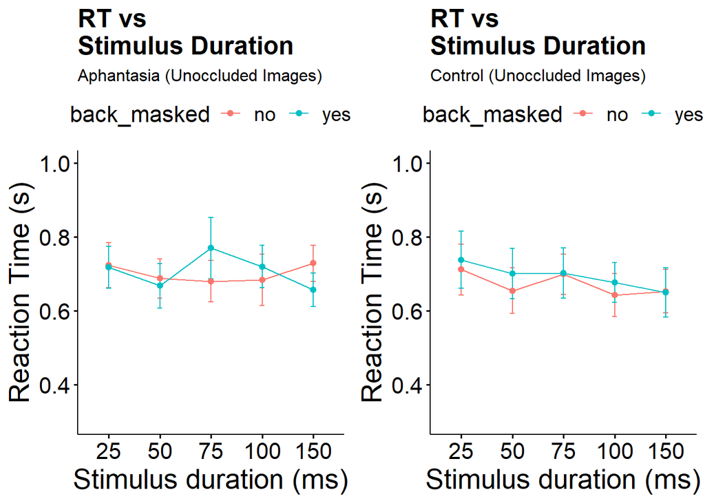

### Modeling RT

#### Occluded Images

Similar to our analysis on accuracy, We ran a linear mixed effects model to test trends in reaction time. The model also included stimulus duration (SOA), back masking, and aphantasia group as fixed effects and participant as a random intercept.

Reaction_time ~ Stimulus_duration x back_masking x aphantasia + (1|participant)

|  | RT |  |  |
| --- | --- | --- | --- |
| Predictors | Estimates | CI | p |
| (Intercept) | 0.72 | 0.60 – 0.84 | **<0.001** |
| SOA | -0.00 | -0.00 – 0.00 | 0.706 |
| aphantasia2 [yes] | 0.17 | -0.00 – 0.35 | 0.053 |
| back masked [yes] | 0.04 | -0.03 – 0.11 | 0.311 |
| SOA * aphantasia2 [yes] | -0.00 | -0.00 – -0.00 | **0.027** |
| SOA * back masked [yes] | -0.00 | -0.00 – 0.00 | 0.857 |
| aphantasia2 [yes] * back masked [yes] | 0.02 | -0.08 – 0.12 | 0.677 |
| (SOA * aphantasia2 [yes]) * back masked [yes] | -0.00 | -0.00 – 0.00 | 0.539 |
| Random Effects |  |  |  |
| σ<sup>2</sup> | 0.02 |  |  |
| τ<sub>00</sub> <sub>participant</sub> | 0.10 |  |  |
| ICC | 0.81 |  |  |
| N <sub>participant</sub> | 59 |  |  |
| Observations | 590 |  |  |
| Marginal R<sup>2</sup> / Conditional R<sup>2</sup> | 0.032 / 0.819 |  |  |

#### Unoccluded Images

# Speed-Accuracy Trade-Offs

The above analysis indicates that the aphantasia group had greater categorization accuracy but also longer reaction times than the control group. Because these two findings occurred together, the differences in accuracy could actually reflect differences in speed-accuracy trade-off criterion (where the aphantasia group made slower responses in favour of accuracy).

To test this interpretation, we reran the analysis on occluded images. However this time we used a performance measure known as the Balanced Integration Score (BIS). This measure incorporates both accuracy and reaction time and has been found to be insensitive to speed-accuracy trade-offs. The BIS is taken as the difference between the standardized scores of accuracy and reaction time.

*If the effect of aphantasia group is no longer present in this analysis, we can conclude that the previously observed differences in accuracy most likely reflected differences speed-accuracy trade-off criterion*.

The below graphs plot BIS against stimulus duration, again grouped by back masking and aphantasia group

The data shows trends similar to those observed when we analyzed accuracy. So let’s take a look at another linear mixed model to see if the effects changed.

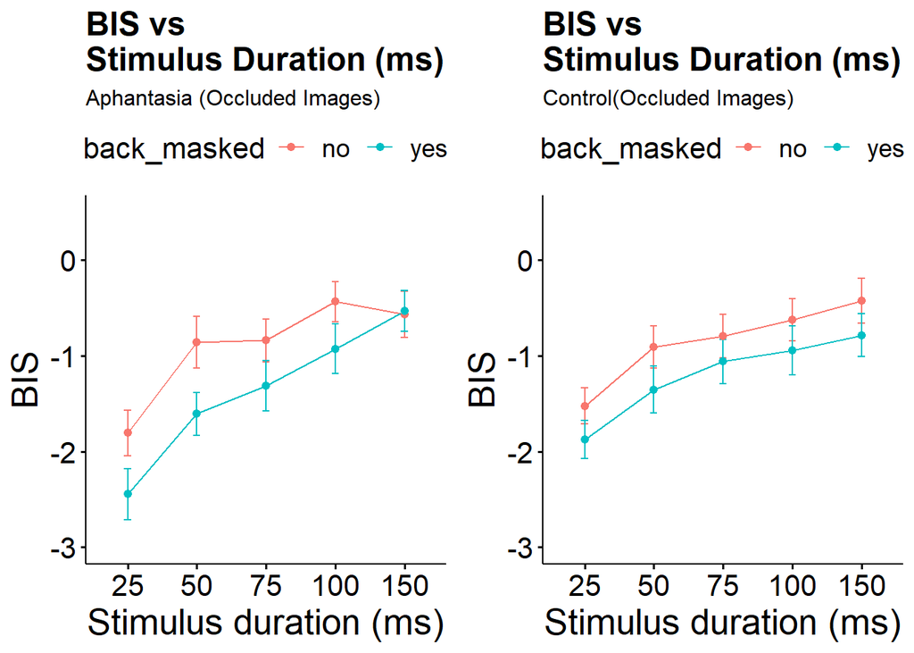

The model includes stimulus duration, back masking, and aphantasia group as fixed effects and participant as a random intercept.

BIS ~ Stimulus_duration x back_masking x aphantasia + (1|participant)

In this model, using a performance measure that incorporates accuracy and reaction time, we see that the effects of stimulus duration (SOA) and back masking are preserved. Most importantly, there remains a significant interaction between back masking and aphantasia group.

However, note that the effect of aphantasia is no longer significant.

|  | bis |  |  |
| --- | --- | --- | --- |
| Predictors | Estimates | CI | p |
| (Intercept) | -1.49 | -1.94 – -1.03 | **<0.001** |
| SOA | 0.01 | 0.01 – 0.01 | **<0.001** |
| back masked [yes] | -0.37 | -0.68 – -0.06 | **0.020** |
| aphantasia2 [yes] | -0.12 | -0.76 – 0.53 | 0.725 |
| SOA * back masked [yes] | 0.00 | -0.00 – 0.00 | 0.885 |
| SOA * aphantasia2 [yes] | 0.00 | -0.00 – 0.00 | 0.617 |
| back masked [yes] * aphantasia2 [yes] | -0.55 | -0.99 – -0.11 | **0.015** |
| (SOA * back masked [yes]) * aphantasia2 [yes] | 0.01 | 0.00 – 0.01 | **0.029** |
| Random Effects |  |  |  |
| σ<sup>2</sup> | 0.42 |  |  |
| τ<sub>00</sub> <sub>participant</sub> | 1.23 |  |  |
| ICC | 0.75 |  |  |
| N <sub>participant</sub> | 59 |  |  |
| Observations | 590 |  |  |
| Marginal R<sup>2</sup> / Conditional R<sup>2</sup> | 0.124 / 0.778 |  |  |

# Conclusions

From this study, we learn that individuals with aphantasia are differentially impacted by visual noise compared to controls.

The presentation of visual noise had a larger negative impact on the aphantasia group, suggesting that their visual processing is more vulnerable to disruption.